# Basic Skills in Visualing Data and Exporatory Data Analysis Using R

Shkedy et al.

# Introduction

It was John W. Tukey who said that “Exploratory data analysis can never be the whole story, but nothing else can serve as the foundation stone - as the first step”. This book provides the guide acquire the fundamental skills in EDA and visualizing data (VD) using R.

## R ?

Only basic knowledge in R is required. We focused on a user level skills rather than on programming skills and we use mainly the and R packages or the basic graphical functions in R.

## Example: the iris data

The iris dataset was used by R.A.Fisher in 1936 to illustrate few methods in multivariate analysis. The data contains information about 4 measurements on 50 flowers from each of 3 species of iris. Sepal length and width, and petal length and width are measured in centimeters. Species are Setosa, Versicolor, and Virginica.In this section we focus on the Sepal length of Setosa.

```r
Sepal.L <- iris$Sepal.Length[iris$Species=="setosa"]
Sepal.L
```

```
##  [1] 5.1 4.9 4.7 4.6 5.0 5.4 4.6 5.0 4.4 4.9 5.4 4.8 4.8 4.3 5.8 5.7 5.4 5.1 5.7
## [20] 5.1 5.4 5.1 4.6 5.1 4.8 5.0 5.0 5.2 5.2 4.7 4.8 5.4 5.2 5.5 4.9 5.0 5.5 4.9
## [39] 4.4 5.1 5.0 4.5 4.4 5.0 5.1 4.8 5.1 4.6 5.3 5.0
```

- What can we say about the distribution of the Sepal length of Setosa ??
- How does the distribution look like ??
- The mean and the median of sepal length are 5.006 and 5 respectively.

```r
c(mean(Sepal.L),median(Sepal.L))
```

```
## [1] 5.006 5.000
```

- Why do we use the mean and the median ?
- What do these values tell us ?

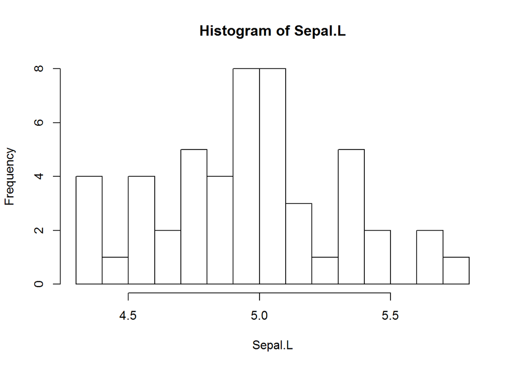

Sepal length (I)

```r
hist(Sepal.L, nclass = 20, col = 0)
```

Alternatively, we can use the function from the R ackage to produce the same histogram. The function is more advanced than the and it allows to produce histograms in a more complex data structures.

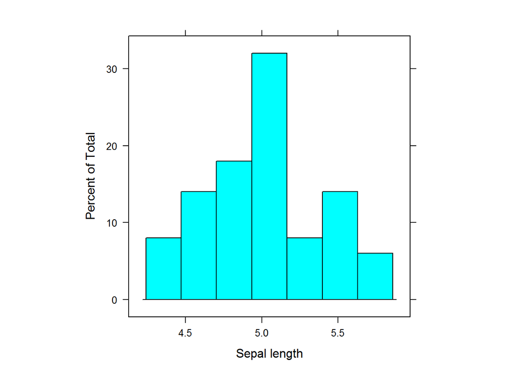

Sepal length (II)

```r
histogram(Sepal.L,
                  layout = c(1, 1),
              aspect = 1,
                 xlab = "Sepal length")
```

A third option to produce a histogram for the sepal length is to use the package and the function with the argument .

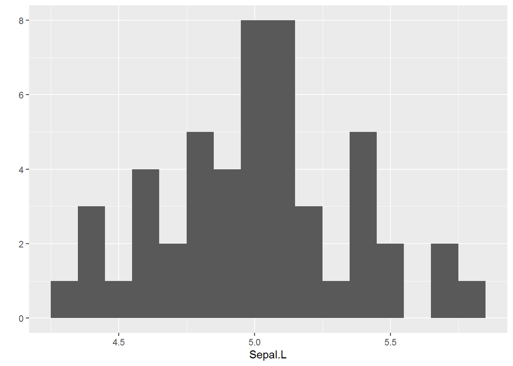

Sepal length (III)

```r
Iris.R<-data.frame(Sepal.L)
qplot(Sepal.L, data = Iris.R, geom = "histogram", binwidth = 0.1)
```

## Book Structure

### Part 1: Location, Spread and Shape in univariate data

In the first part of the book we focus on descriptive measures, numerical and graphical, to characterize the features of a particular univariate distribution. The following three main factors are usually used to specify a paticular distribution:

- Location
- Spread
- Shape

#### Location

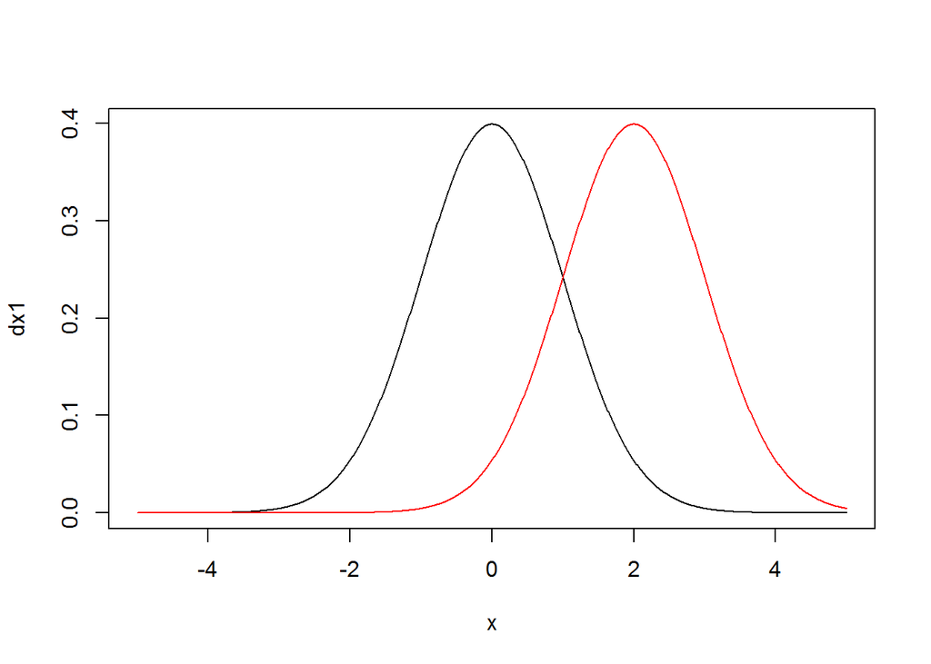

Location

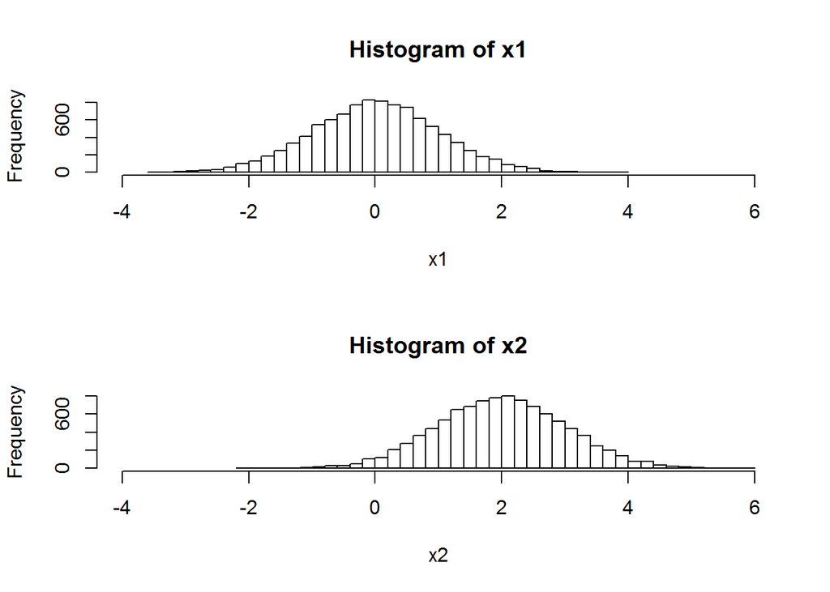

Samples from normal distribution.

```r
x1 <- rnorm(10000, 0, 1)
x2 <- rnorm(10000, 2, 1)
par(mfrow = c(2, 1))
hist(x1, col = 0, nclass = 50, xlim = c(-4, 6))
hist(x2, col = 0, nclass = 50, xlim = c(-4, 6))
```

#### Spread

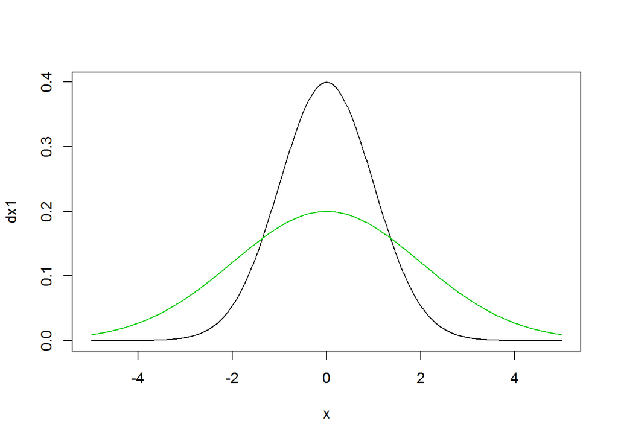

Spread

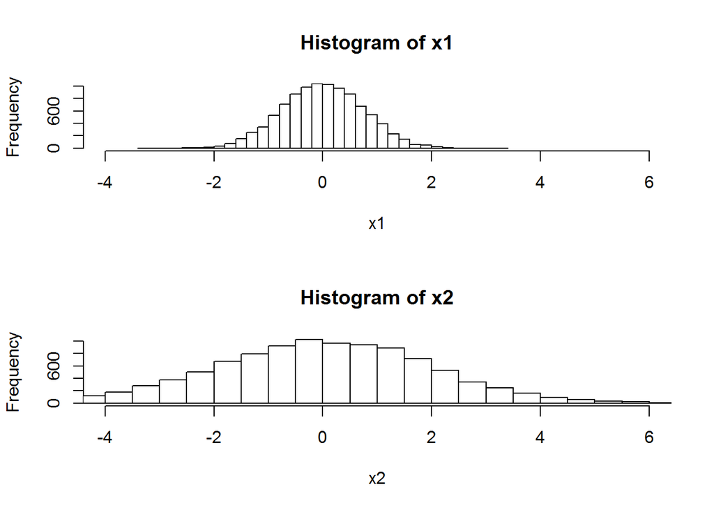

Random samples from normal distribution

#### Shape

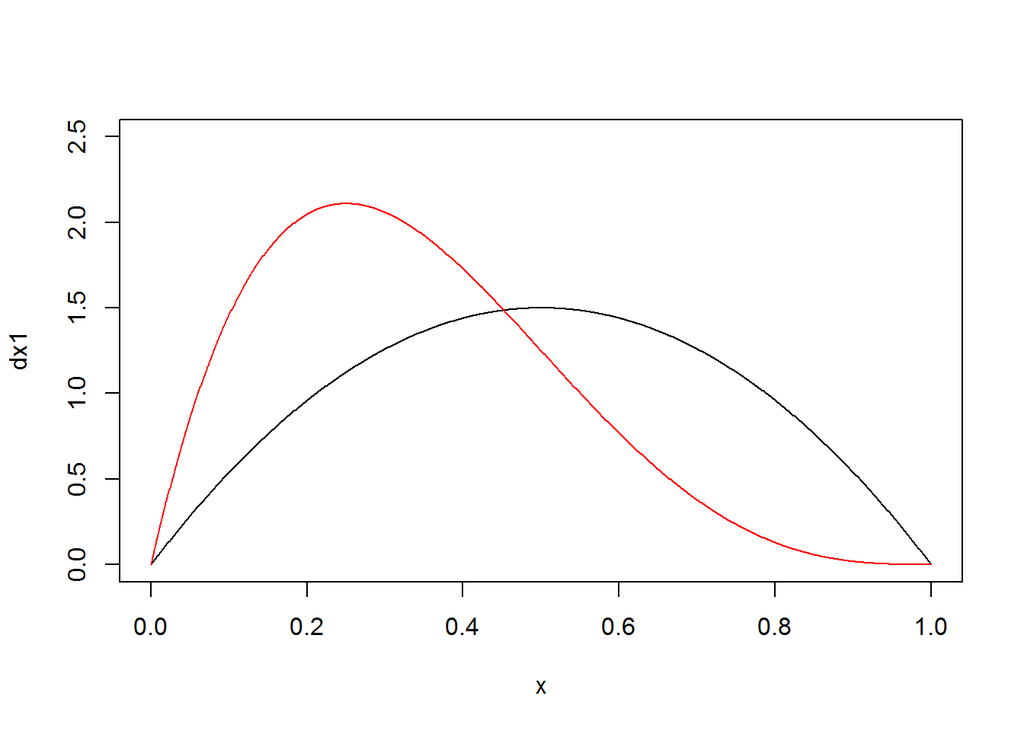

Shape

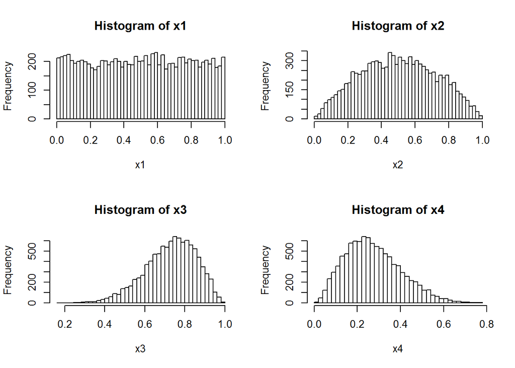

Random Samples from Beta distribution.

# Part 2: Correlation and association in multivariate datasets.

# Part 3:Clustering.

# Part 4: Biclustering

## R, again ?

If you did not have a problem to understand the R code above, you will not have any problem to understand the R code that we use to produce all the output for the examples discuss in this book. If you had a difficulty to understand the code for the examples above you need a short training, at a beginner level, in R.

### YouTube tutorial: introduction to R

For a short online YouTube introduction, by Stuar51XT, see [YTVD1](https://www.youtube.com/watch?v=qHfSTRNg6jE).

### R course online

An introductory course for R is able online in the >eR-BioStat website here [>eR-BioStat](https://github.com/eR-Biostat/Courses/tree/master/Introductory%20Courses/Introduction%20to%20R).

## R datasets for illustraions

- Part 1
  - The singers data: [singers](https://stat.ethz.ch/R-manual/R-devel/library/lattice/html/singer.html).
  - The airquality data: [airquality](https://stat.ethz.ch/R-manual/R-devel/library/datasets/html/airquality.html)
  - The cars data: [cars](https://stat.ethz.ch/R-manual/R-devel/library/datasets/html/cars.html)
  - The Iris data: [iris](https://stat.ethz.ch/R-manual/R-devel/library/datasets/html/iris.html)
  - The Old Faithful Geyser Data: [oldfaithful](https://stat.ethz.ch/R-manual/R-patched/library/datasets/html/faithful.html)
  - The beavers data: [beavers](https://stat.ethz.ch/R-manual/R-patched/library/datasets/html/beavers.html)
- Part 2

## NBA data

For many examples we use NDA data about different teams and different players. Data were download from the basketball reference website [NBA](https://www.basketball-reference.com/leagues/NBA_2020_per_game.html). The NBA data consists of performance indicators (on a team and individual levels) and we use the data to illustrate visualization tools to detect and present trend s/structures in the data.

# The 5-number summary and stem-and-leaf

## Introduction

In a given dataset we want to know

- Which values seems to be typical - Location ?
- How much variation there is in the data - Spraed?
- How the distribution of the data looks like - Shape?

## Sorting and ranking the sample

Consider a sample of size 5 from $N(0,2^{2})$ : $x_{1},x_{2},x_{3},x_{4},x_{5}$

```r
x <- rnorm(5, 0, 2)
x
```

```
## [1] -3.452171 -2.290075  1.086829 -1.616477 -2.519063
```

The Ordered sample is the sample sorted from the lowest to the highest value: $x_{(1)},x_{(2)},x_{(3)},x_{(4)},x_{(5)}$

```r
sort(x)
```

```
## [1] -3.452171 -2.519063 -2.290075 -1.616477  1.086829
```

## Numerical summaries for sample distribution

### Median ($M$)

The center of the sample in terms of counting. $\frac{1}{2}$ of the observations are smaller or equals to the median and  
$\frac{1}{2}$ are greater than the median.

```r
 median(x) #note that the sample size is 5
```

```
## [1] -2.290075
```

If the sample size is even then

```r
y <- c(10, 2, 50, 6, 100, 25)
sort(y)
```

```
## [1]   2   6  10  25  50 100
```

```r
median(y) #=(10+25)/2
```

```
## [1] 17.5
```

### The extremes

The smallest and the largest values in the data.

```r
min(y)
```

```
## [1] 2
```

```r
max(y)
```

```
## [1] 100
```

```r
range<-max(y)-min(y)
range
```

```
## [1] 98
```

### Lower and Upper fourth

The lower fourth ($F_{L}$) is the value that $\frac{1}{4}$ of the observations are smaller or equals to and $\frac{3}{4}$ of the observations are greater than $F_{L}$. The upper forth ($F_{U}$) is the value that $\frac{3}{4}$ of the observations are smaller or equals to and $\frac{1}{4}$ of the observations are greater than $F_{U}$.

## Summary of a single sample

### The 5-number summary

The idea is to summaries the information in the data with 5 numbers: The median, the fourths and the extremes, $x_{1},F_{L},M,F_{U},x_{n}$.

In R, The 5-number summary of a sample $x=(x_{1},\dots,x_{n})$ can be produced using the function .

### Online tutorials

#### YouTube tutorial: 5 number summary

For a short online YouTube introduction, by Simple Learning Pro, about Five number Boxplots, and Outliers with R see [YTVD2](https://www.youtube.com/watch?v=tpToLyZibKM).

#### YouTube tutorial: stem-and-leaf plot

For a short online YouTube introduction, by Ed Boone, stem-and-leaf using R see [YTVD3](https://www.youtube.com/watch?v=GjSimgjUkII).

### Example: the old faithful geyser data

The Old faithful geyser data gives information about the Waiting time between eruptions and the duration of the eruption for the Old Faithful geyser in Yellowstone National Park, Wyoming, USA. The duration of the eruption are listed below.

```r
faithful$eruptions
```

```
##   [1] 3.600 1.800 3.333 2.283 4.533 2.883 4.700 3.600 1.950 4.350 1.833 3.917
##  [13] 4.200 1.750 4.700 2.167 1.750 4.800 1.600 4.250 1.800 1.750 3.450 3.067
##  [25] 4.533 3.600 1.967 4.083 3.850 4.433 4.300 4.467 3.367 4.033 3.833 2.017
##  [37] 1.867 4.833 1.833 4.783 4.350 1.883 4.567 1.750 4.533 3.317 3.833 2.100
##  [49] 4.633 2.000 4.800 4.716 1.833 4.833 1.733 4.883 3.717 1.667 4.567 4.317
##  [61] 2.233 4.500 1.750 4.800 1.817 4.400 4.167 4.700 2.067 4.700 4.033 1.967
##  [73] 4.500 4.000 1.983 5.067 2.017 4.567 3.883 3.600 4.133 4.333 4.100 2.633
##  [85] 4.067 4.933 3.950 4.517 2.167 4.000 2.200 4.333 1.867 4.817 1.833 4.300
##  [97] 4.667 3.750 1.867 4.900 2.483 4.367 2.100 4.500 4.050 1.867 4.700 1.783
## [109] 4.850 3.683 4.733 2.300 4.900 4.417 1.700 4.633 2.317 4.600 1.817 4.417
## [121] 2.617 4.067 4.250 1.967 4.600 3.767 1.917 4.500 2.267 4.650 1.867 4.167
## [133] 2.800 4.333 1.833 4.383 1.883 4.933 2.033 3.733 4.233 2.233 4.533 4.817
## [145] 4.333 1.983 4.633 2.017 5.100 1.800 5.033 4.000 2.400 4.600 3.567 4.000
## [157] 4.500 4.083 1.800 3.967 2.200 4.150 2.000 3.833 3.500 4.583 2.367 5.000
## [169] 1.933 4.617 1.917 2.083 4.583 3.333 4.167 4.333 4.500 2.417 4.000 4.167
## [181] 1.883 4.583 4.250 3.767 2.033 4.433 4.083 1.833 4.417 2.183 4.800 1.833
## [193] 4.800 4.100 3.966 4.233 3.500 4.366 2.250 4.667 2.100 4.350 4.133 1.867
## [205] 4.600 1.783 4.367 3.850 1.933 4.500 2.383 4.700 1.867 3.833 3.417 4.233
## [217] 2.400 4.800 2.000 4.150 1.867 4.267 1.750 4.483 4.000 4.117 4.083 4.267
## [229] 3.917 4.550 4.083 2.417 4.183 2.217 4.450 1.883 1.850 4.283 3.950 2.333
## [241] 4.150 2.350 4.933 2.900 4.583 3.833 2.083 4.367 2.133 4.350 2.200 4.450
## [253] 3.567 4.500 4.150 3.817 3.917 4.450 2.000 4.283 4.767 4.533 1.850 4.250
## [265] 1.983 2.250 4.750 4.117 2.150 4.417 1.817 4.467
```

The 5 number summary for the duration of the eruption is

```r
quantile(faithful$eruptions)
```

```
##      0%     25%     50%     75%    100%
## 1.60000 2.16275 4.00000 4.45425 5.10000
```

### Stem-and-leaf display

Stem-and-leaf enables to organize the data graphically in a way that directs our attention to the main pattern in the data. This is a basic and simple but very effective tool to visualize the pattern in the data.

#### Constructing stem-and-leaf:

- data value $\Longrightarrow$ split $\Longrightarrow$ stem and leaf
- 10.5 $\Longrightarrow$ $10|5$ $\Longrightarrow$ 10 and 5

We use the R function to obtained the stem-and-leaf, for the Old faithful geyser data we use

```r
stem(faithful$eruptions)
```

```
##
##   The decimal point is 1 digit(s) to the left of the |
##
##   16 | 070355555588
##   18 | 000022233333335577777777888822335777888
##   20 | 00002223378800035778
##   22 | 0002335578023578
##   24 | 00228
##   26 | 23
##   28 | 080
##   30 | 7
##   32 | 2337
##   34 | 250077
##   36 | 0000823577
##   38 | 2333335582225577
##   40 | 0000003357788888002233555577778
##   42 | 03335555778800233333555577778
##   44 | 02222335557780000000023333357778888
##   46 | 0000233357700000023578
##   48 | 00000022335800333
##   50 | 0370
```

The stem-and-leaf plot of the Old faithful geyser data reveals a bimodel for the duration ofeuroption.

## The 5-number summary and samples comparison

### The beaver data

The beaver dataset, pblished by Reynolds (1994), describes a small part of a study of the long-term temperature dynamics of beaver Castor canadensis in north-central Wisconsin. Body temperature was measured by telemetry every 10 minutes for four females.For illusrtraion we use data obtaioned for two beavers and focused on the body temperature in a specific day. A part of the data for one beaver are listed below.

```r
head(beaver1[beaver1$day==346& beaver1$activ==0,])
```

```
##   day time  temp activ
## 1 346  840 36.33     0
## 2 346  850 36.34     0
## 3 346  900 36.35     0
## 4 346  910 36.42     0
## 5 346  920 36.55     0
## 6 346  930 36.69     0
```

### A comparison between the two beavers

The stem-and-leaf plot and 5 number summry are shown below

```r
temp1<-beaver1[beaver1$day==346& beaver1$activ==0,]$temp
stem(temp1)
```

```
##
##   The decimal point is 1 digit(s) to the left of the |
##
##   363 | 345
##   364 | 2
##   365 | 04559
##   366 | 224577999
##   367 | 145567789
##   368 | 011234555567777889999999
##   369 | 111222334445567788999
##   370 | 0001259
##   371 | 08
##   372 | 00013
```

```r
quantile(temp1)
```

```
##      0%     25%     50%     75%    100%
## 36.3300 36.7525 36.8800 36.9575 37.2300
```

For the second veaver we have

```r
temp2<- beaver2[beaver2$day==307 & beaver2$activ==0,]$temp
stem(temp2)
```

```
##
##   The decimal point is 1 digit(s) to the left of the |
##
##   364 | 8
##   366 | 3
##   368 | 90035577899
##   370 | 0114472223445577
##   372 | 34488
##   374 | 411
##   376 | 4
```

```r
quantile(temp2)
```

```
##      0%     25%     50%     75%    100%
## 36.5800 36.9725 37.0950 37.1700 37.6400
```

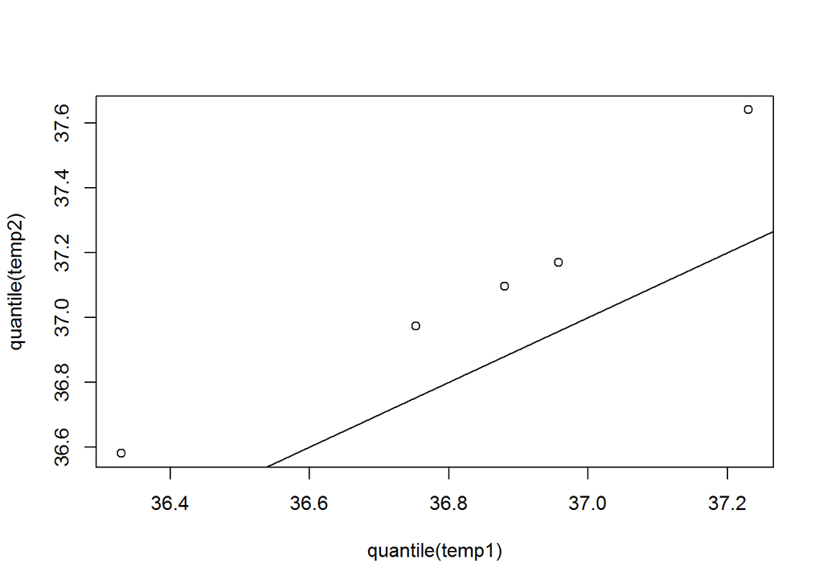

the 5 number summary of two beaver

```r
plot(quantile(temp1),quantile(temp2))
abline(0,1)
```

## Example: Magic Johnson and Larry Bird’s rookie season in the NBA

Magic Johnson (https://en.wikipedia.org/wiki/Magic_Johnson) and Larry Bird (https://en.wikipedia.org/wiki/Larry_Bird) are two NBA legends who came to the league in the season of 1979/1980. The Battles between the Lakers and the Celtics in their time is considered by many as one of the most intense rivalry in NBA history. In this section we compare two stat performance indicators, the number of field goals attempts(FGA) and the number of assist (AST) per game between Johnson and Bird in their rookie season. The R objects that contains that data are (Larry Bird) and (Magic Johnson).

```r
LB <- read.csv("C:/projects/NBA/LBMJ/LB_1979_RS.csv",header = TRUE,sep =",")
MJ <- read.csv("C:/projects/NBA/LBMJ/MJ_1979_RS.csv",header = TRUE,sep =",")
k<-12 #FGA
#k<-23 #AST
x1<-na.omit(LB[,k])
x2<-na.omit(MJ[,k])
```

### Field goal attempts (FGA) per game

```r
xx<-data.frame(c("MEJ","LB"),c(mean(x2),mean(x1)))
names(xx)<-c("Player","Average")
xx
```

```
##   Player  Average
## 1    MEJ 12.32468
## 2     LB 17.63235
```

The stem-and-leaf diagram below shows that Bird’s mode of FGA is between 15-19 compare to Johnson’s mode FGA which is between 10-12. It also shows that Bird’s FPA per game is more variable compare to Johnson’s FGA per game.

```r
stem(x1)
```

```
##
##   The decimal point is 1 digit(s) to the right of the |
##
##   0 | 69
##   1 | 0012222244444444
##   1 | 5555555556666777777778888899999
##   2 | 00111112244
##   2 | 557799
##   3 | 02
```

```r
q.lb<-quantile(x1)
q.lb
```

```
##    0%   25%   50%   75%  100%
##  6.00 14.00 17.00 20.25 32.00
```

```r
stem(x2)
```

```
##
##   The decimal point is at the |
##
##    2 | 00
##    4 | 0
##    6 | 00000
##    8 | 0000000
##   10 | 000000000000000000
##   12 | 0000000000000000000
##   14 | 00000000
##   16 | 0000000
##   18 | 00000000
##   20 | 0
##   22 | 0
```

```r
q.mej<-quantile(x2)
q.mej
```

```
##   0%  25%  50%  75% 100%
##    2   10   12   15   22
```

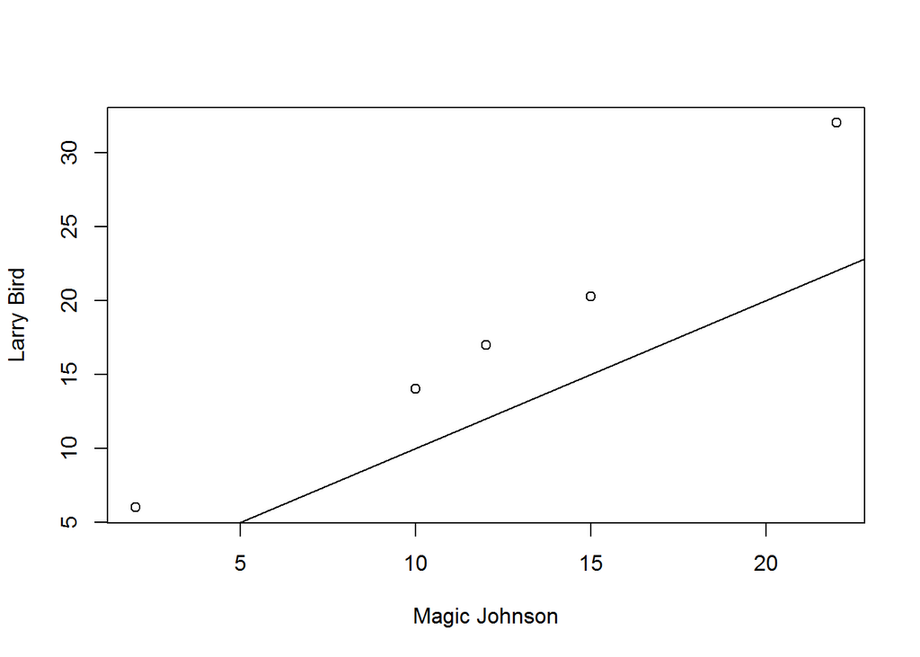

FGA: the 5 number summary of Magic Johnson and Larry Bird

```r
plot(q.mej,q.lb,xlab="Magic Johnson",ylab="Larry Bird")
abline(0,1)
```

### Number of asists (AST) per game

In his rookie season Magic Johnson passed 7.31 assists per game much higher than Larry Bird’s 4.63 assists per game.

```r
k<-23 #AST
x1<-na.omit(LB[,k])
x2<-na.omit(MJ[,k])
xx<-data.frame(c("MEJ","LB"),c(mean(x2),mean(x1)))
names(xx)<-c("Player","Average")
xx
```

```
##   Player  Average
## 1    MEJ 7.311688
## 2     LB 4.637681
```

The stem-and-leaf diagram shows that Magic Johnson AST distribution is located to the right and has higher variability compare to Larry Bird’s distribution.

```r
stem(x1)
```

```
##
##   The decimal point is at the |
##
##    1 | 00
##    2 | 00000
##    3 | 00000000000000
##    4 | 000000000000000
##    5 | 00000000000000
##    6 | 000000
##    7 | 0000000
##    8 | 0000
##    9 | 0
##   10 | 0
```

```r
q.lb<-quantile(x1)
q.lb
```

```
##   0%  25%  50%  75% 100%
##    1    3    4    6   10
```

```r
stem(x2)
```

```
##
##   The decimal point is at the |
##
##    2 | 000000
##    4 | 0000000000000
##    6 | 0000000000000000000000000
##    8 | 00000000000000000
##   10 | 0000000000
##   12 | 000000
```

```r
q.mej<-quantile(x2)
q.mej
```

```
##   0%  25%  50%  75% 100%
##    2    6    7    9   13
```

Note how Magic Johnson’s 5 number summary and laying (almost parallel) below the $45^{o}$ lines.

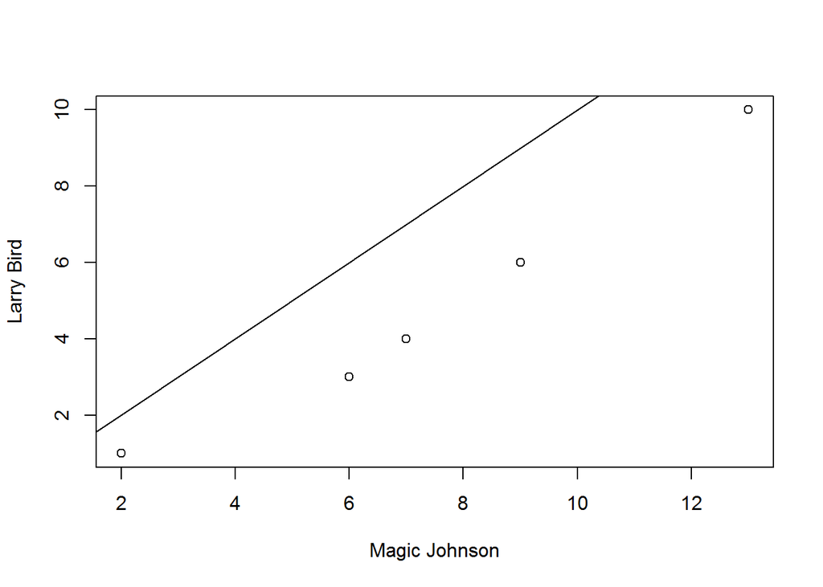

AST: the 5 number summary of Magic Johnson and Larry Bird

```r
plot(q.mej,q.lb,xlab="Magic Johnson",ylab="Larry Bird")
abline(0,1)
```

# Location, location, location…

## Location and location parameter

The location of a distribution is the center of the distribution. This is the place where the data are concentrated. When several distributions have the same shape and width but are shifted relative to each other, then the location parameter is a measure of this shift. For example, consider a normal distribution with variance $\sigma^{2}=1$ and mean $\mu$, its density function given by
$$f(x,\mu,1)=\frac{1}{\sqrt{2 \pi}}e^-{\frac{(x- \mu)^{2}}{2}}.$$

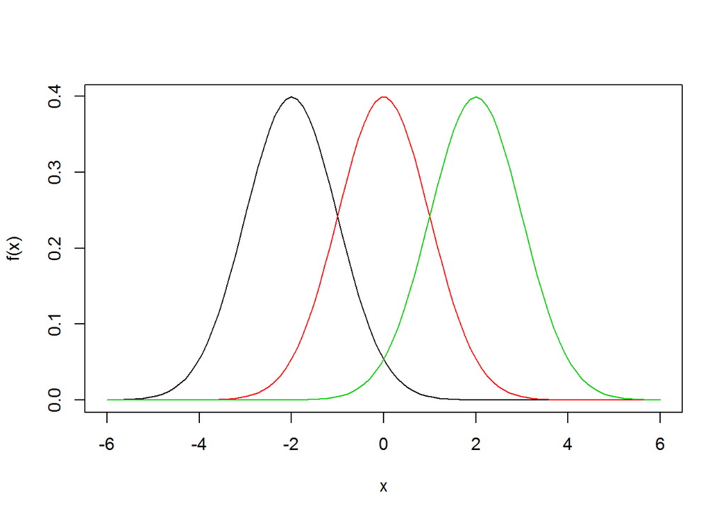

Location

```r
x<-seq(from=-6,to=6,length=100)
dx1<-dnorm(x,-2,1)
dx2<-dnorm(x,0,1)
dx3<-dnorm(x,2,1)
plot(x,dx1,type="l",xlab="x",ylab="f(x)")
lines(x,dx2,col=2)
lines(x,dx3,col=3)
```

Figure~1 shows three density functions of the normal distribution with $\mu=-2,0$ and $2$. The three distributions are shifted relative to each other and the value of $\mu$ determines the shift.

## Location estimators

The sample mean, median and the trimmed mean are all estimators that can be used to estimate the location parameter. They belong to the class of $L-estimators$ which implies that these estimators are a linear function of the observations. Let $X_{1},X_{2}......X_{n}$ be a sample of size $n$. The sorted values $X_{(1)} \le X_{(2)} \le \dots \le X_{(n)}$, from smallest to largest , are called the order statistic. For example, consider the sample 35, 80, 105, 96 and 35. The sorted values are 35, 35, 80, 96,105 imply that, $X_{(1)}=35$, $X_{(3)}=80$ and the maximum $X_{(5)}=105$. Let $X_{(1)} \le X_{(2)} \le \dots \le X_{(n)}$ be the order statistics of a sample of size $n$, and let $a_{1},a_{2} \dots , a_{n}$ be weights such that $0 \le a_{i} \le 1$ and $\sum_{i=1}^{n}a_{i}=1$. An L-estimator, $T_{L}$, with weights $a_{1},a_{2} \dots, a_{n}$ is
$$T_{L}=\sum_{i=1}^{n}a_{i}X_{(i)}$$

### Examples

#### YouTube tutorial: calculating Mean, Median, Range, Minimum and Maximum using R studio

For a short online YouTube tutorial, by BIO-RESEARCH, about the mean, median etc, using R see [YTVD4](https://www.youtube.com/watch?v=nkSl9hwh-dQ).

#### The sample mean

Let $a_{i}=\frac{1}{n}$ for $i=1,2, \dots ,n$. Then
$$T=\sum_{i=1}^{n}a_{i}X_{(i)}=\sum_{i=1}^{n}\frac{1}{n}X_{(i)}=\bar{X}$$
In out example the sample mean is $\bar{X}=\frac{1}{5}(35+35+80+96+105)=70.2$.

```r
x<-c(35,35,80,96,105)
mean(x)
```

```
## [1] 70.2
```

#### The median

The median is the value such that $50 \%$ of the data are less than or equal to. When $n$ is odd, the median is equal to $X_{(\frac{n-1}{2} +1)}$. For example, the median of $35, 80, 105, 96,35$ is 80, which is also $X_{(3)}$.

```r
sort(x)
```

```
## [1]  35  35  80  96 105
```

```r
median(x)
```

```
## [1] 80
```

If we define the weights
$$a_{i}= \left \{ \begin{array}{ll}
1 & \mbox{if $i=\frac{n-1}{2}+1$}\\
0 & \mbox{otherwise}
\end{array}
\right.$$

then it follows that
$$T=\sum_{i=1}^{n}a_{i}X_{(i)}=1 \times X_{(\frac{n-1}{2}+1)}= Median$$
When $n$ is even then
$$a_{i}= \left \{ \begin{array}{ll}
0.5 & \mbox{if $i=\frac{n}{2},\frac{n}{2}+1$}\\
0 & \mbox{otherwize}
\end{array}
\right.$$
and the median is $\frac{1}{2}X_{(\frac{n}{2})}+\frac{1}{2}X_{(\frac{n}{2}+1)}$.

#### The trimmed mean

The trimmed mean is the mean of the sample obtained after trimming a certain proportion of the observations at the upper and lower tails. For example, consider a sample of size 10: The $10 \%$-trimmed mean , $T(0.2)$, is the average of the 8 observations

which remain after trimming $10\%$ of the observations at each tail, i.e the largest and the smallest values of the sample (25 and 94). The $10 \%$-trimmed mean is therefore obtained by discarding $20 \%$ of the data (hence the notaion $T(0.2)$). In this example $T(0.2)=57.875$. In R, we use the function with the argument .

```r
x<-c(25,27,39,57,57,63,69,75,76,94)
mean(x,trim=0.1)
```

```
## [1] 57.875
```

A $20 \%$-trimmed mean, $T(0.4)$, is the average of the data after trimming $20 \%$ of the data at each side, i.e.
$$T(0.4)=\frac{1}{6}\sum_{i=3}^{8} x_{(i)}=\frac{1}{6}(39+57+57+63+69+75)=60$$

which can be calculate in R by

```r
mean(x,trim=0.2)
```

```
## [1] 60
```

The $\alpha \%$-trimmed mean belongs to the L-estimators class. If we define
$$a_{i}= \left \{ \begin{array}{ll}
\frac{1}{n-2 \alpha n} & \mbox{if $\;\; n \alpha +1 \le i \le n - n \alpha$}\\
0 & \mbox{otherwise}
\end{array}
\right.$$
then in our example, for $n=10$ and $\alpha=0.2$ ($40\%$ of the observations are trimmed), we have: $n-2 \alpha n= 10-4=6$, $n \alpha + 1 =3$ and $n-n \alpha = 8$ and
$$T(2 \alpha)=\sum_{i=1}^{n}a_{i}X_{(i)}= \frac{1}{n-2 \alpha n} \sum_{i=n \alpha +1 }^{n-n \alpha} X_{(i)}=
\frac{1}{6}\sum_{i=3}^{8} X_{(i)}$$

## The data

The dataset is a data frame in R contints information about daily air quality measurements in New York, May to September 1973. We focus on the daily mean ozone in parts per billion from 1300 to 1500 hours at Roosevelt Island. Data are shwon below

```r
print(airquality$Ozone)
```

```
##   [1]  41  36  12  18  NA  28  23  19   8  NA   7  16  11  14  18  14  34   6
##  [19]  30  11   1  11   4  32  NA  NA  NA  23  45 115  37  NA  NA  NA  NA  NA
##  [37]  NA  29  NA  71  39  NA  NA  23  NA  NA  21  37  20  12  13  NA  NA  NA
##  [55]  NA  NA  NA  NA  NA  NA  NA 135  49  32  NA  64  40  77  97  97  85  NA
##  [73]  10  27  NA   7  48  35  61  79  63  16  NA  NA  80 108  20  52  82  50
##  [91]  64  59  39   9  16  78  35  66 122  89 110  NA  NA  44  28  65  NA  22
## [109]  59  23  31  44  21   9  NA  45 168  73  NA  76 118  84  85  96  78  73
## [127]  91  47  32  20  23  21  24  44  21  28   9  13  46  18  13  24  16  13
## [145]  23  36   7  14  30  NA  14  18  20
```

Figure~2 shows the histogram for the ozone level. An equivalent information can be seen in the stem-and-leaf diagram.

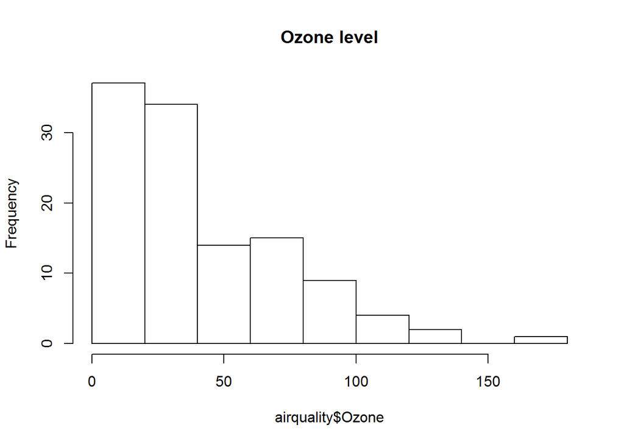

Histogram for the ozone level

```r
hist(airquality$Ozone,main="Ozone level")
```

```r
stem(airquality$Ozone)
```

```
##
##   The decimal point is 1 digit(s) to the right of the |
##
##    0 | 1467778999
##    1 | 01112233334444666688889
##    2 | 0000111123333334478889
##    3 | 001222455667799
##    4 | 01444556789
##    5 | 0299
##    6 | 134456
##    7 | 13367889
##    8 | 024559
##    9 | 1677
##   10 | 8
##   11 | 058
##   12 | 2
##   13 | 5
##   14 |
##   15 |
##   16 | 8
```

The distributiion is skwed to the right. This means that most of the days have a low ozone level while a (relarivly) small proportion of the days have a high ozone level. The ozone level for these days are located in the right tell of the distribution.

The mean ozone level is 42.12.

```r
Ozone1<-na.omit(airquality$Ozone)
 mean(Ozone1)
```

```
## [1] 42.12931
```

The sample mean infeluences from the higher ozone leves at the right tail of the distribution and therefore is higher than the median (31.5) which is the average of the two centeral values of the sample.

```r
median(Ozone1)
```

```
## [1] 31.5
```

```r
mean(Ozone1, trim = 0.2)
```

```
## [1] 34.8
```

## The number of 3 points attempt per game (3PA) made by the Golden State Warriors: 2010-2019

The Golden State Worrier is one of the dominant team in the NBA during the second decade of the 21 century. The team won 3 championships (2014/2015,2017/2018,2018/2019) and 5 Conference titles. The data frame contain information about the three points attempts (per game) made by the GSW players during the regular season’s games between 28/10/2009 and 10/04/2019. The team played 739 games during this period and made 7084 attempts for three points.

```r
load("C:\\projects\\NBA\\GSW\\GSW1.RData")
head(xxx)
```

```
##   A3P YEAR
## 1   1 2010
## 2   3 2010
## 3   2 2010
## 4   1 2010
## 5   2 2010
## 6   2 2010
```

```r
length(xxx$A3P)
```

```
## [1] 739
```

```r
sum(xxx$A3P)
```

```
## [1] 7084
```

Our aim in the section is to visualized the pattern in the number of 3 point appends over the years. The total number of 3 points attempts increased from 380 in 2010 to 1339 in 2019.

```r
tapply(xxx$A3P,xxx$YEAR,sum)
```

```
## 2010 2011 2012 2013 2014 2015 2016 2017 2018 2019
##  380  342  121  606  615  646  886  789 1360 1339
```

This trend can be detected when we use the mean and median of the number of 3 points attempts (3PA) per game as a summery statistics over the years. Notice how the median number of 3PA increases from 4 in 2010 to 17 in 2019.

```r
tapply(xxx$A3P,xxx$YEAR,mean)
```

```
##      2010      2011      2012      2013      2014      2015      2016      2017
##  4.750000  4.621622  4.653846  7.670886  7.884615  8.075000 11.215190  9.987342
##      2018      2019
## 16.585366 16.329268
```

```r
tapply(xxx$A3P,xxx$YEAR,median)
```

```
## 2010 2011 2012 2013 2014 2015 2016 2017 2018 2019
##  4.0  4.5  4.0  8.0  7.5  8.0 11.0 10.0 16.0 17.0
```

Both mean and median summarized the distribution of 3PA using one number, the location estimator. We can visualize the shift in 3PA using the stem-and-leaf plot discussed in the previous chapter. For example, the right shift in the 3PA’s distribution can be clearly seen when we compare the stem-and-leaf plot of 2010 and 2018 (the last championship’s season)

```r
stem(xxx$A3P[xxx$YEAR=="2010"])
```

```
##
##   The decimal point is at the |
##
##    0 | 00000
##    2 | 00000000000000000000000
##    4 | 000000000000000000000000
##    6 | 0000000000000
##    8 | 0000000000
##   10 | 00000
```

```r
stem(xxx$A3P[xxx$YEAR=="2018"])
```

```
##
##   The decimal point is at the |
##
##    6 | 000
##    8 | 000000
##   10 | 00000000
##   12 | 00000000
##   14 | 0000000000000
##   16 | 0000000
##   18 | 0000000000
##   20 | 000000
##   22 | 000000000000000
##   24 | 0000
##   26 | 0
##   28 |
##   30 | 0
```

The shift can be detected when we use the 5 number summary to compare the 3PA distribution between the two years.

```r
quantile(xxx$A3P[xxx$YEAR=="2010"])
```

```
##   0%  25%  50%  75% 100%
##    0    2    4    6   11
```

```r
quantile(xxx$A3P[xxx$YEAR=="2018"])
```

```
##    0%   25%   50%   75%  100%
##  6.00 12.25 16.00 21.75 30.00
```

# Graphical display for location

## Online tutorials

### YouTube tutorial: A dotplot using the package

For a short online YouTube tutorial, by ramstatvid, about dotplot using the package see [YTVD5](https://www.youtube.com/watch?v=-FGU6PMaSRY).

### YouTube tutorial: A dotplot using the package

For a short online YouTube tutorial, by ramstatvid, about dotplot using the package see [YTVD6](https://www.youtube.com/watch?v=y1CsT-jAWZQ)

## The singer dataset

The singer datset is a data frame giving the heights of singers in the New York Choral Society. The variables are named height (inches) and voice.part which is the voice group of the singer (altos, sporanos, tenors and bass) Note that each voice group is subdivied into to groups, high voice and low voice (for example Bass1 and Bass2 and the lower and higher Bass voices, respectivly). Graphical despalys in the section were produced using the R package lattice. The first 6 observatioans are given below.

```r
head(singer)
```

```
##   height voice.part
## 1     64  Soprano 1
## 2     62  Soprano 1
## 3     66  Soprano 1
## 4     65  Soprano 1
## 5     60  Soprano 1
## 6     61  Soprano 1
```

The display in Figure~3 is a strip plot which plots the data of each voice group in a different strip. Figure~3 shows that there is a clear pattern in the data: it is easy to distinguish between women (Sopranos and Altos) and men (Tenors and Basses). Women are clearly shorter than men. However, this is not the only pattern that can be detected in the data.

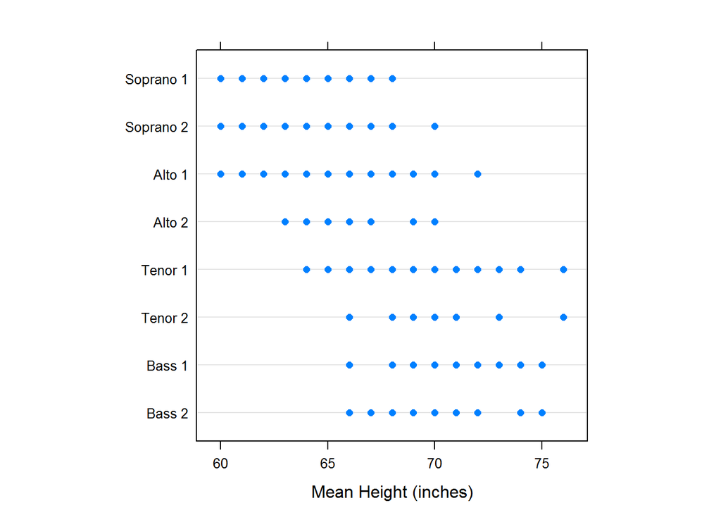

The singer dataset: dotplot by voice group using the lattice package

```r
dotplot(singer$voice.part~singer$height,
        aspect=1,
        xlab="Mean Height (inches)")
```

An equivalent strip plot, show in Figure~XX, can be produced using the package. The function implies that observatios with the same values will be ploted side by side will not overlap so sample size would be seen as well in the plot.

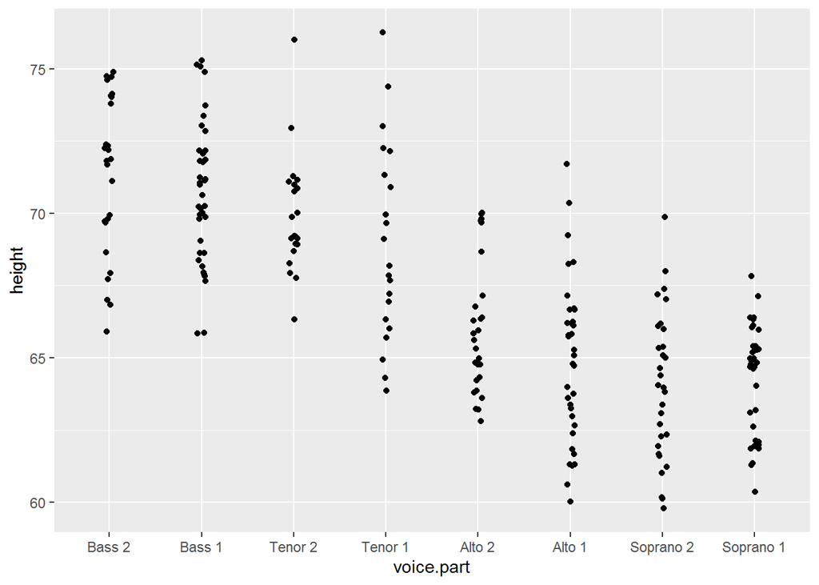

Dotplot using the gg2plot package

```r
ggplot(singer, aes(voice.part,height)) + geom_jitter(position = position_jitter(width = .05))
```

In order to get a better insight of other patterns, we can summarize the distribution of each group with the sample mean. In R this can be done using the function . A general call of the function has the form

To calculate mean of height by the voice group in the singer dataset we use

```r
attach(singer)
tapply(singer$height,singer$voice.part,mean)
```

```
##    Bass 2    Bass 1   Tenor 2   Tenor 1    Alto 2    Alto 1 Soprano 2 Soprano 1
##  71.38462  70.71795  69.90476  68.90476  66.03704  64.88571  63.96667  64.25000
```

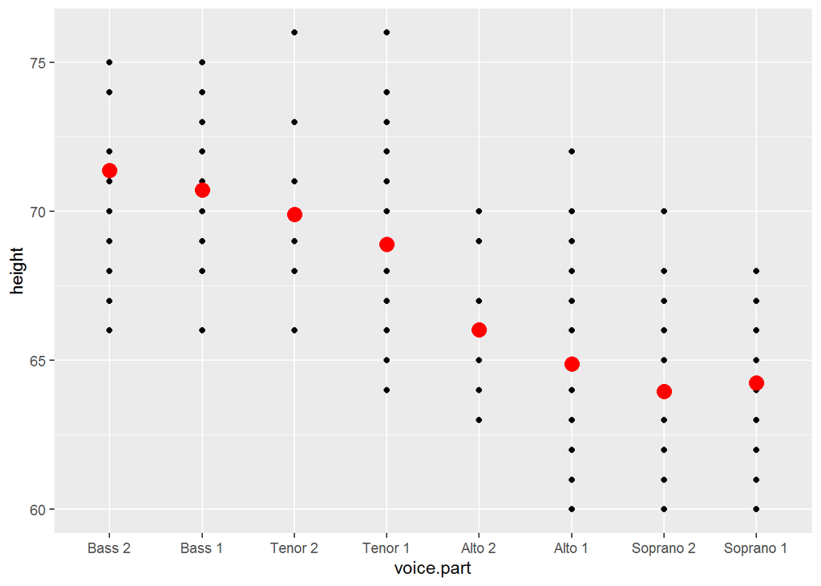

```r
ggplot(singer, aes(voice.part,height)) +
geom_point() +
stat_summary(geom = "point", fun.y = "mean", colour = "red", size = 4)
```

Another display of the location of each distribution is the box plot in Figure~XXX. In this figure, the location of each group is summarized by the median (the dot inside the box). Other aspects of this plot will be discussed in later chapters)

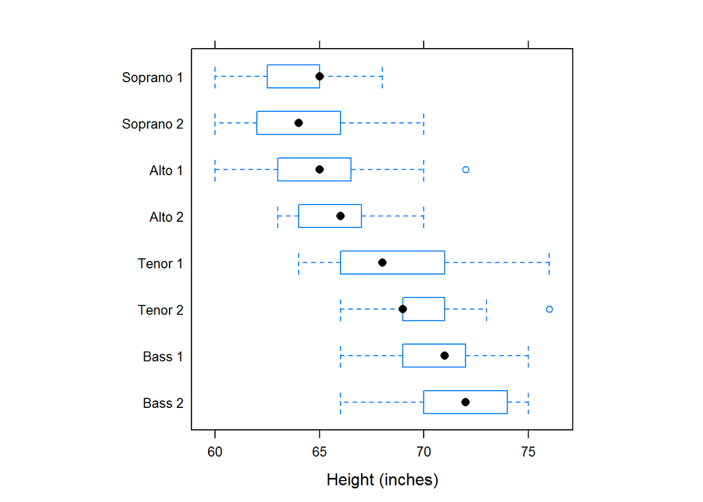

Side by side boxplots by voice group.

```r
bwplot(as.factor(singer$voice.part)~ singer$height,
        data=singer,
        aspect=1,
        xlab="Height (inches)")
```

The multiway histogram in Figure~XXXX shows the distributions of heights across the voice groups. Note how the distribution of height is shiffted from left to right across the voice levels.

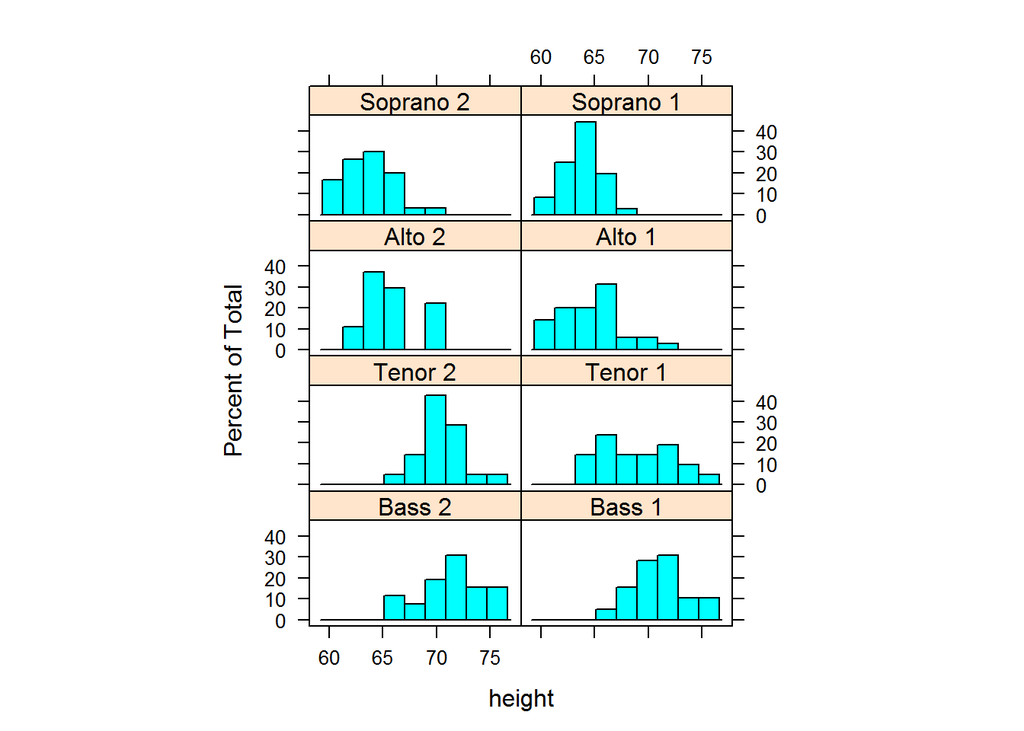

Histogra by voice group

```r
histogram(~ singer$height | singer$voice.part,
        data=singer,
          layout = c(2, 4),
          aspect = 0.5,
       xlab = "height")
```

An equivalent multiway histogram can be produce with the package using addtional two layers in the basic plot, the first layer spacifys the plot type while the second layer indicates the factor for the plot partions, the function

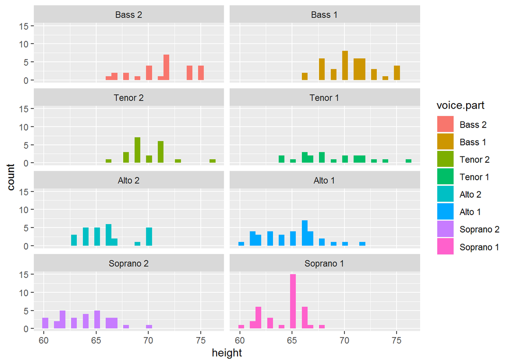

```r
ggplot(singer, aes(height,fill = voice.part)) +
geom_histogram() +
facet_wrap(~voice.part,ncol = 2)
```

## Online tutorial:

### YouTube tutorial: Histogram using

For a short online YouTube tutorial, by ramstatvid, about histogram using the package see [YTVD7](https://www.youtube.com/watch?v=hxQmEhzgWks)

### Web tutorial: Histograms using

The the R Graph Gallery provide code for advance histogram visualization using the package. For examples of histograms see [WMVD1](https://www.r-graph-gallery.com/histogram.html)

## Michael Jordan’s game score in championship years

Michael Jordan is arguably the greatest basketball player of all time (https://en.wikipedia.org/wiki/Michael_Jordan). During his career he won 6 NBA championships, in the seasons of 90/91, 91/92 92/93 and 95/96, 96/97, 97/98. He retired after the third chptionshiop and made first comeback to win the other three. He retired again form the game after the 97/98 season and made a comeback in the season 2001/2002 and 02/03. In this section we focus on Michael Jordan’s game score in his 6 championship seasons.

```r
load("C:\\projects\\NBA\\MJKB\\MJ2.RData")
load("C:\\projects\\NBA\\MJKB\\MJ3.RData")
```

The mean GmSc in the regular season games is given below and shows a decreasing pattern from the first three championship to the second three-peat.

```r
tapply(xx21$x.rs,xx21$y.rs,mean)
```

```
##     1991     1992     1993     1996     1997     1998
## 26.21341 24.43875 25.51538 23.43537 22.13171 20.01951
```

The same pattern is observed for the GmSc in the playoff games.

```r
tapply(xx21.po$x.po,xx21.po$y.po,mean)
```

```
##     1991     1992     1993     1996     1997     1998
## 27.42941 25.07727 26.17368 21.93333 22.22105 22.18571
```

We can visualize the distribution of the GmSc by year using the function of the package . Note that the R object is the year and the object is the GmSc.

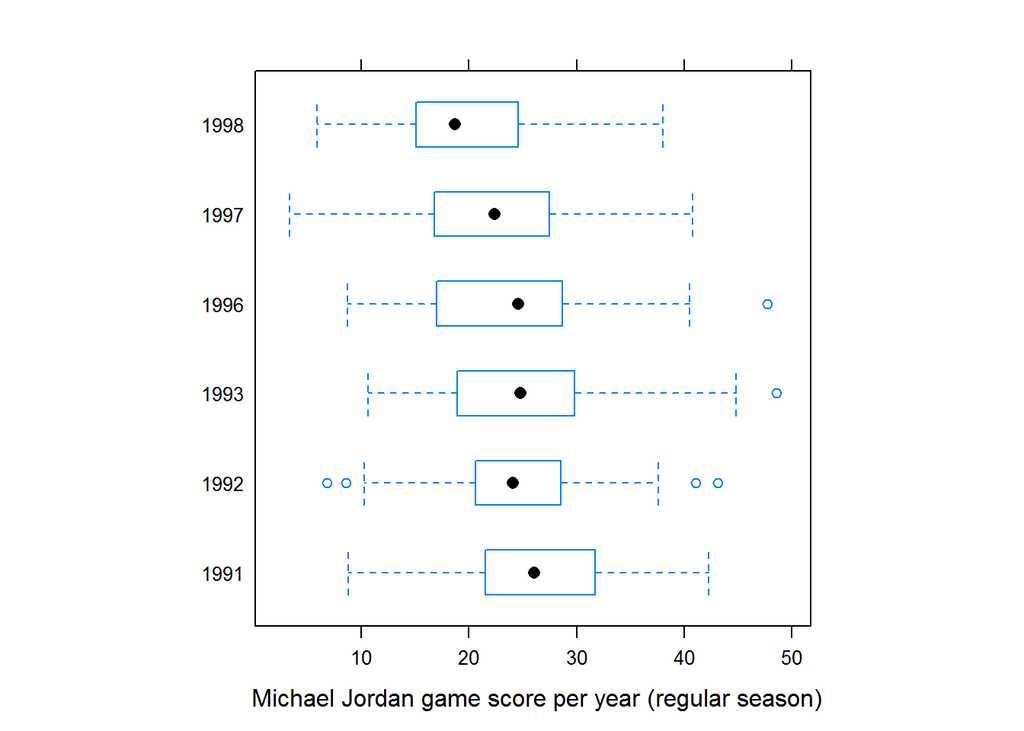

Boxplot for MJ game score in championchip years

```r
  bwplot(xx21$y.rs~xx21$x.rs,
                data = xx21,
                layout = c(1, 1),
                aspect = 1,
                xlab = " Michael Jordan game score per year (regular season)")
```

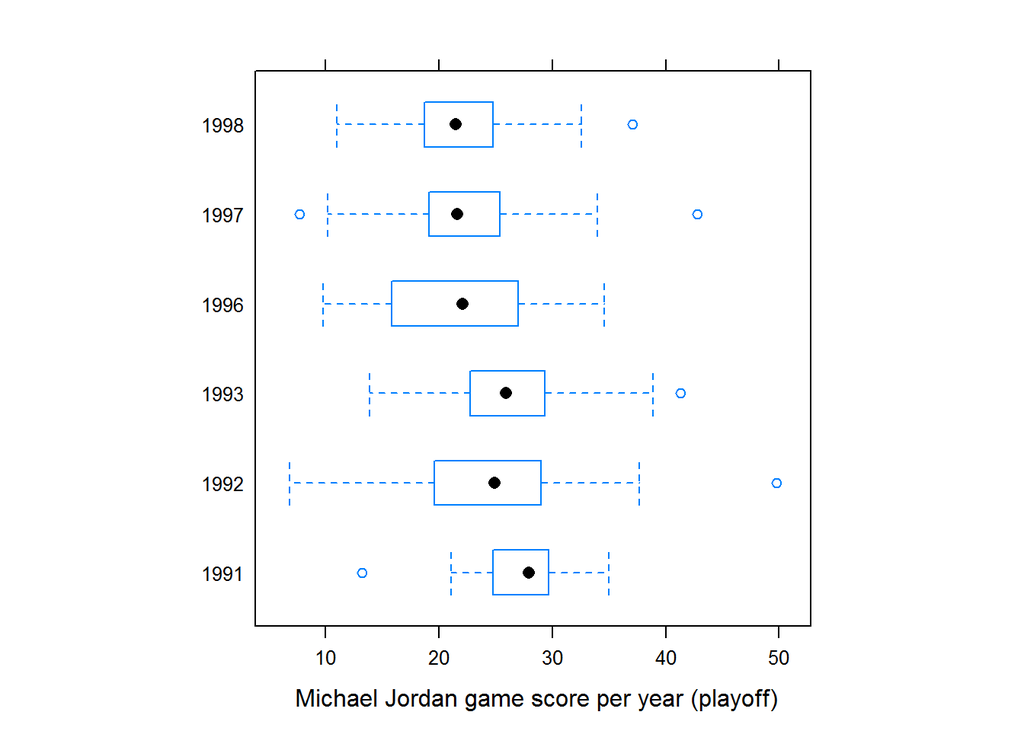

Boxplot for MJ game score in championchip years

```r
   bwplot(xx21.po$y.po~xx21.po$x.po,
                data = xx21.po,
                layout = c(1, 1),
                aspect = 1,
                xlab = " Michael Jordan game score per year (playoff)")
```

A dotplot of MJ game score with both mean and median as numerical summaries for location can be produce using the function with the options and , respectively. The smooth line is added using the function .

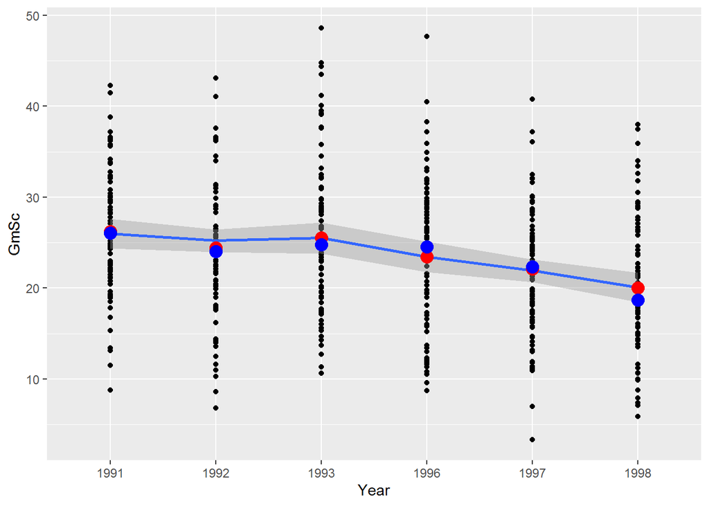

Dotplot for MJ game score in championchip years (regular season)

```r
ggplot(xx21, aes(xx21$y.rs,xx21$x.rs)) +
geom_point() +
geom_smooth(aes(group=1))+
stat_summary(geom = "point", fun.y = "mean", colour = "red", size = 4)+
stat_summary(geom = "point", fun.y = "median", colour = "blue", size = 4)+
xlab("Year")+
ylab("GmSc")
```

The dotplot for the playoff can be produced in a similar way.

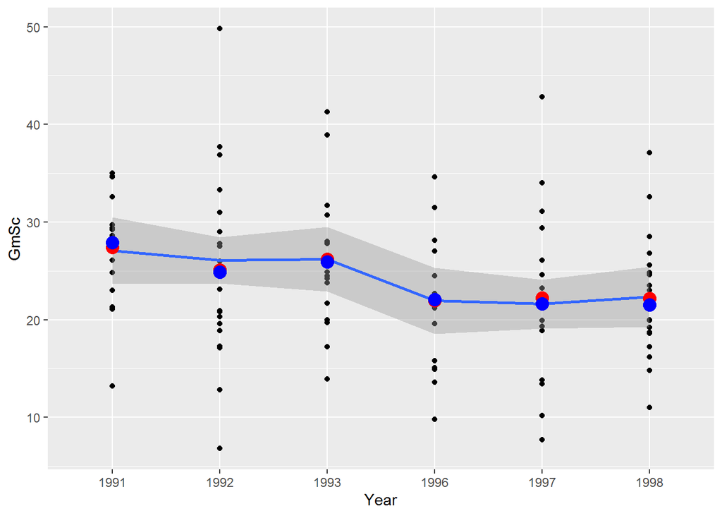

Dotplot for MJ game score in championchip years (playoff).

```r
ggplot(xx21.po, aes(xx21.po$y.po,xx21.po$x.po)) +
geom_point() +
geom_smooth(aes(group=1))+
stat_summary(geom = "point", fun.y = "mean", colour = "red", size = 4)+
stat_summary(geom = "point", fun.y = "median", colour = "blue", size = 4)+
xlab("Year")+
ylab("GmSc")
```

```r
#grid.arrange(p1, p2, nrow = 1)
```

## The number of 3 points attempt made by the Golden State Warriors: 2010-2019

In the previous chapter we saw that the median number of 3 points attempts per game made by GSW players increased from 4 in 2010 to 17 in 2019. In total, GSW had 739 games during this period in which the team attempt 7084 three points shots.

```r
load("C:\\projects\\NBA\\GSW\\GSW1.RData")
head(xxx)
```

```
##   A3P YEAR
## 1   1 2010
## 2   3 2010
## 3   2 2010
## 4   1 2010
## 5   2 2010
## 6   2 2010
```

```r
length(xxx$A3P)
```

```
## [1] 739
```

```r
sum(xxx$A3P)
```

```
## [1] 7084
```

The mean of3PA per game by year is shown below

```r
mx<-tapply(xxx$A3P,xxx$YEAR,mean)
vx<-tapply(xxx$A3P,xxx$YEAR,var)
data.frame(mx,vx)
```

```
##             mx        vx
## 2010  4.750000  7.050633
## 2011  4.621622  3.745280
## 2012  4.653846  6.315385
## 2013  7.670886  7.787731
## 2014  7.884615 10.389111
## 2015  8.075000  7.158861
## 2016 11.215190  9.812074
## 2017  9.987342  6.833171
## 2018 16.585366 28.961759
## 2019 16.329268 32.075429
```

The boxplot below, produce using the function of the package reveals clearly the increasing pattern over time. A general call of the function have the form . In our example we use

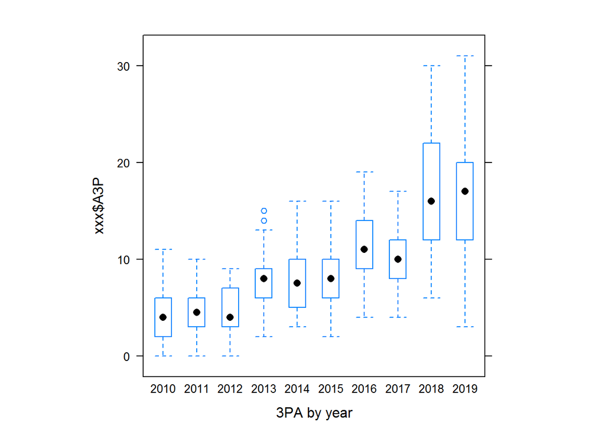

Boxplot over time (the lattice package)

```r
   bwplot(xxx$A3P~xxx$YEAR,
                data = xxx,
                layout = c(1, 1),
                aspect = 1,
                xlab = "3PA by year")
```

A dotplot for the 3PA over time in which the sample mean is used as numerical summary for location is shown in Figure~XX. Note that the mean was added to the plot using the function

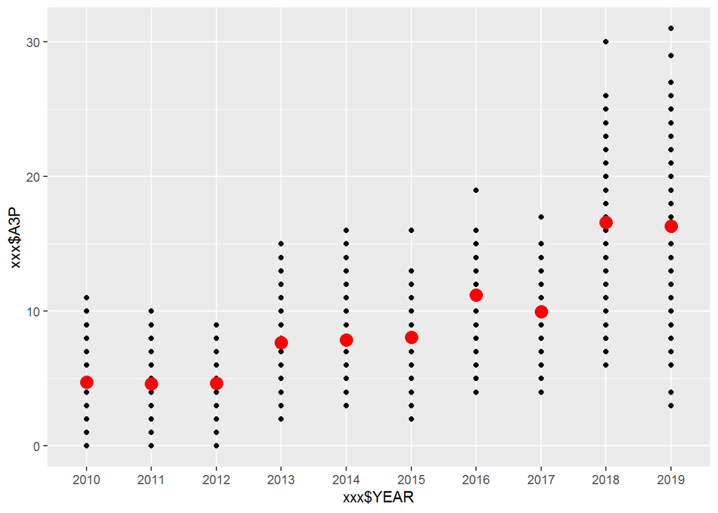

Dotplot over time (the gg2plot package)

```r
ggplot(xxx, aes(xxx$YEAR,xxx$A3P)) +
geom_point() +
stat_summary(geom = "point", fun.y = "mean", colour = "red", size = 4)
```

Both figures reveal that the variability in the number of 3 point attempts increase with the time (as expected, since the number of 3PA is a count variable for which the variability depends on the mean). This can also be seen in Figure~XX below.

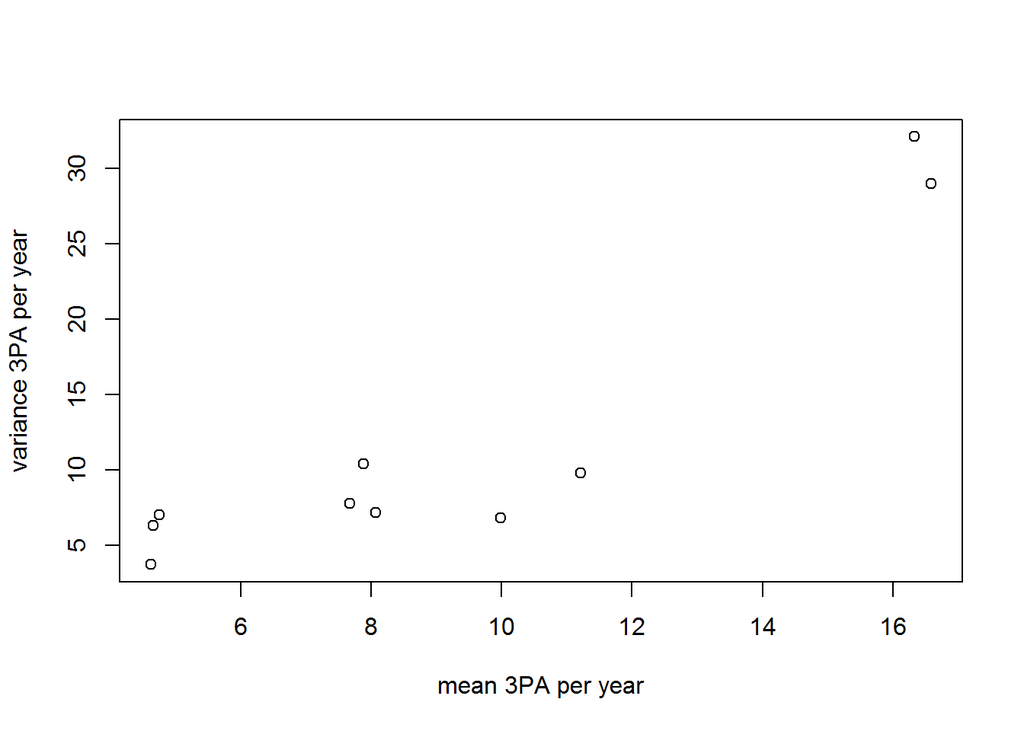

3PA: mean versus variability over time.

```r
plot(mx,vx,xlab="mean 3PA per year",ylab="variance 3PA per year")
```

```r
cor(mx,vx,method = c("spearman"))
```

```
## [1] 0.7939394
```

# Spread

## Main concepts

Both samples are symmetric around 0, the location estimators for both sample are the same. The data in the first sample range from -1 to 1, in the second sample the data range from -50 to 50. The variablity in the second sample is higher. In this section we will focus on estimators to measure the variablity of the sample.

## Spread estimators

#### Sample variance

The most simple measure for spread is the sample variance given by:
$$S_{X}^{2}=\frac{1}{n-1}\sum_{i=1}^{n}\left (X_{i}-\bar{X} \right )^2.$$

#### Fourth-spared

The fourth-spread is the difference between the $75 \%$ and the $25 \%$ quantiles of the data. It is the range of $50\%$ of the data in the center of the distribution and therefore it is more robust estimator than the variance since it is not influenced from outliers at the tails as the variance. Consider a sample of 8 observations:
$$24,\underbrace{35,39,50,60,60}_{60-35=25},75,80$$
the fourth-spread is 25 and the sample variance $S_{x}^{2}=382.9$. Now, suppose that we change the sample to
$$24,\underbrace{35,39,50,60,60}_{60-35=25},75,800$$
the fourth-spread remains the same but the sample variance now is equal to 70762.98.

#### MAD - Median Absolute Deviation

Another robust measure of spread is the MAD, which is the Median of the Absolute Deviation form the median, given by
$$MAD=Median|X_{i}-M|$$
where $M$ is the sample median, $M =Median(X_{1},X_{2} \dots ,X_{j}, \dots ,X_{n})$. In our example the median is 55, when we subtract the median we have $(-31,-20,-16,-5,5,5,20,25)$. The MAD is the median of the absolute values, in this example the MAD is 18.

```r
xi <- c(24,35,39,50,60,60,75,80)
median(xi)
```

```
## [1] 55
```

```r
xi-median(xi)
```

```
## [1] -31 -20 -16  -5   5   5  20  25
```

```r
abs(xi-median(xi))
```

```
## [1] 31 20 16  5  5  5 20 25
```

```r
sort(abs(xi-median(xi)))
```

```
## [1]  5  5  5 16 20 20 25 31
```

```r
median(abs(xi-median(xi)))           # the MAD
```

```
## [1] 18
```

```r
xi[8] <- 800                       # change the maximum value to 800
xi
```

```
## [1]  24  35  39  50  60  60  75 800
```

```r
mad(xi,constant=1)                 # calculate the MAD
```

```
## [1] 18
```

## Boxplot: A graphical display for spread and location

Boxplot is a graphical display which shows the location, the spread and the shape of the distribution. The location is summarized by the median, the spread is summarized by the fourth-spread which is simply the length of the box in the boxplot (the shape will be discussed in chapter 4). Figure~ shows histograms and boxplots for random samples of 1000 observations from $N(0,1)$ and $N(0,3^{2})$.

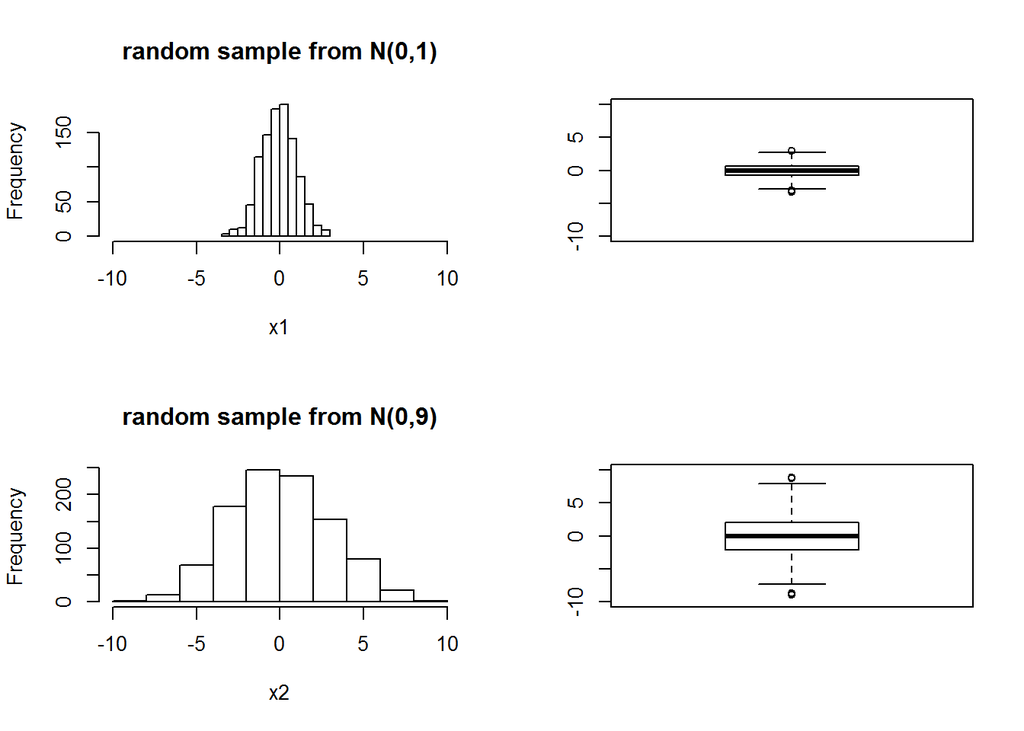

Samples from normal distributions.

```r
x1<-rnorm(1000,0,1)
par(mfrow=c(2,2))
hist(x1,main="random sample from N(0,1)",xlim=c(-10,10))
boxplot(x1,ylim=c(-10,10))
x2<-rnorm(1000,0,3)
hist(x2,main="random sample from N(0,9)",xlim=c(-10,10))
boxplot(x2,ylim=c(-10,10))
```

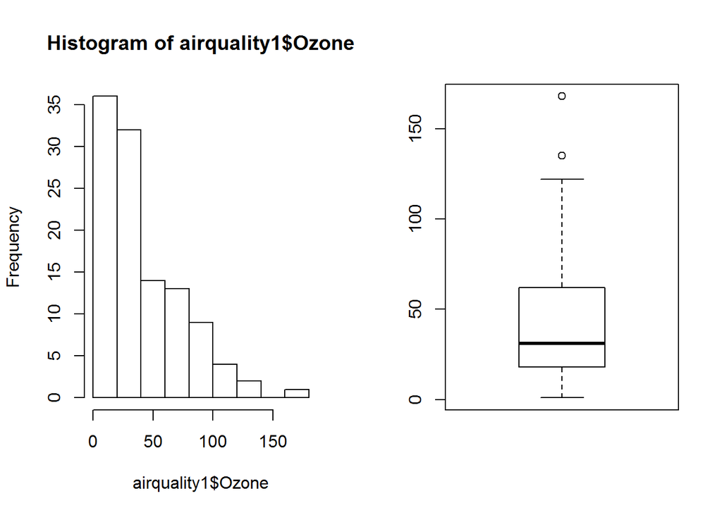

Histogram and boxplot for the airquality data.

```r
par(mfrow=c(1,2))
airquality1<-na.omit(airquality)
hist(airquality1$Ozone)
boxplot(airquality1$Ozone)
```